# Descriptive Statistics and Decision Tree

### 2.a) Make a frequency distribution table for the gender variable to see the frequency distribution

```r
library(readxl)
Exercise <-read_excel("hw1.xls")
View(Exercise)

colnames(Exercise) <- c("weight","height","gender","exerciseperweek","Isregularexercise","friedfoodperweek")
gendertable <- table(Exercise$gender)
```

### 2.b) Make a bar chart for gender variable

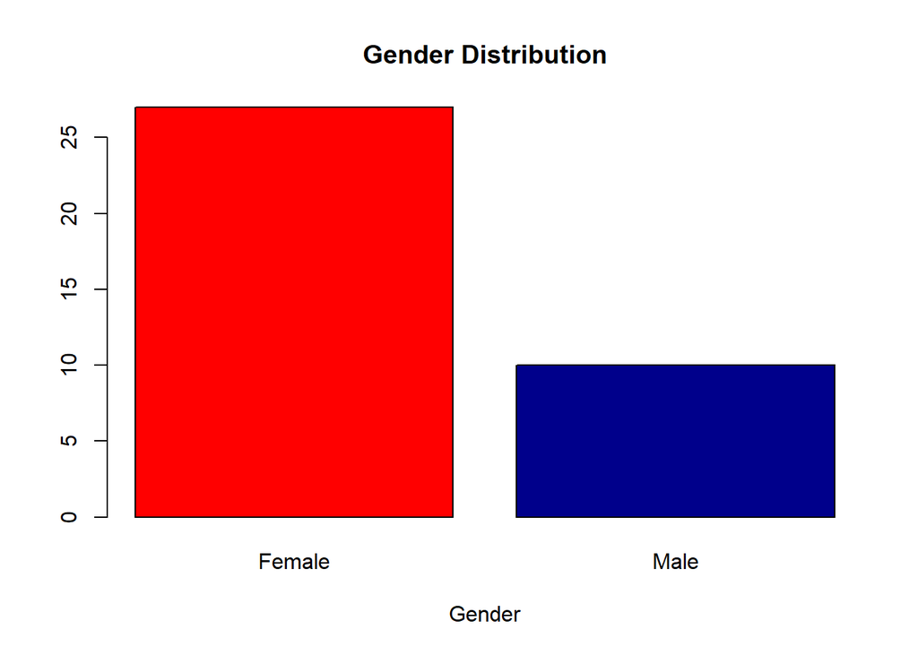

```r
barplot(gendertable,main="Gender Distribution",xlab="Gender",col=c("red","darkblue"))     #col is used for colour
```

### 2.c) Make a histogram to display the distribution of the Height variable

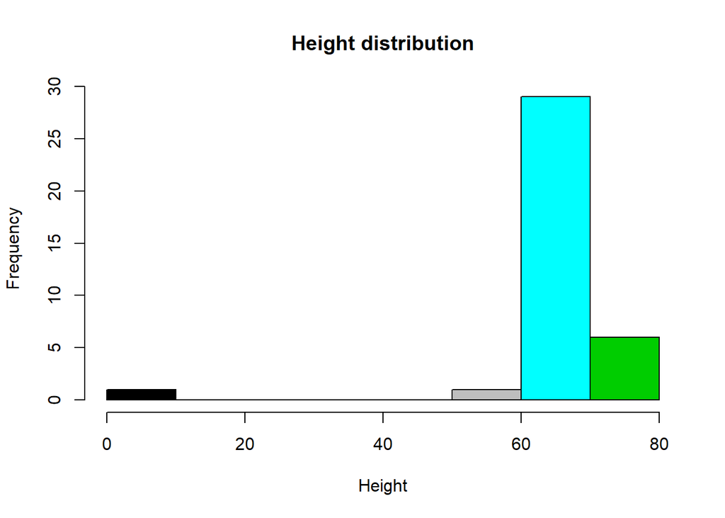

```r
hist(Exercise$height,main="Height distribution",xlab="Height",col = Exercise$height)
```

### 2.d) Make a cluster bar chart (side-by-side bar chart) to examine the correlation between gender and Ate Fried Food variables.

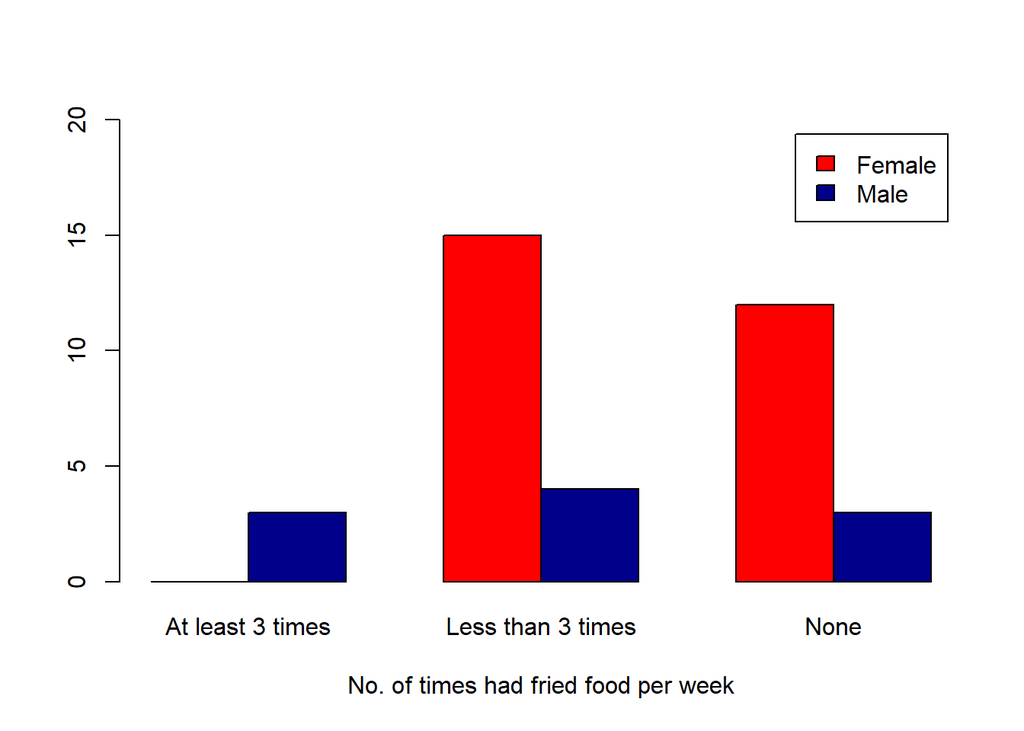

```r
t <-table(Exercise$gender,Exercise$friedfoodperweek)
barplot(t,beside = TRUE,legend=TRUE,xlab = "No. of times had fried food per week",col = c("red","darkblue"),ylim = c(0,20))
```

### 2.e) Make a scatter plot to examine the correlation between Weight and Height variables, and write a sentence to describe the trend you observed from the scatter plot.

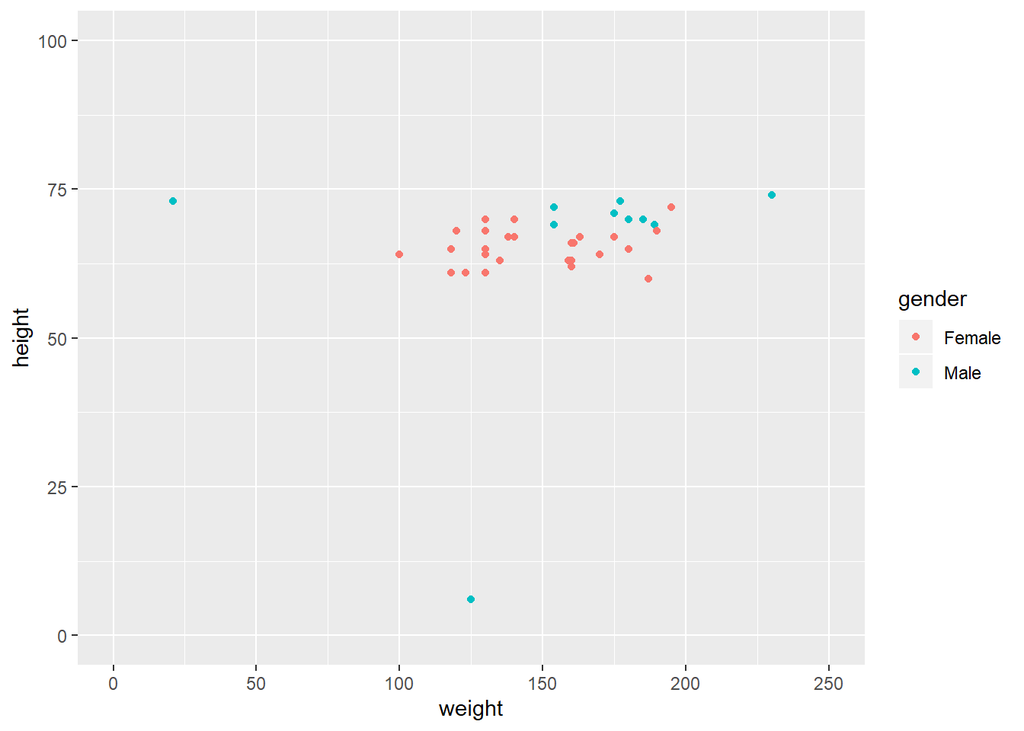

```r
library(ggplot2)
s <-ggplot(Exercise,aes(x=weight,y=height))
s+ geom_point(aes(colour=gender)) +ylim(0,100)+xlim(0,250)
```

```r
#The graph of height Vs Weight is linear with slope zero.
```

### 2.f) Find the 5-number summary for the Height data and make a boxplot for the Height data with mild and extreme outliers identiï¬ed using inner and outer fences. Draw the boxplot.

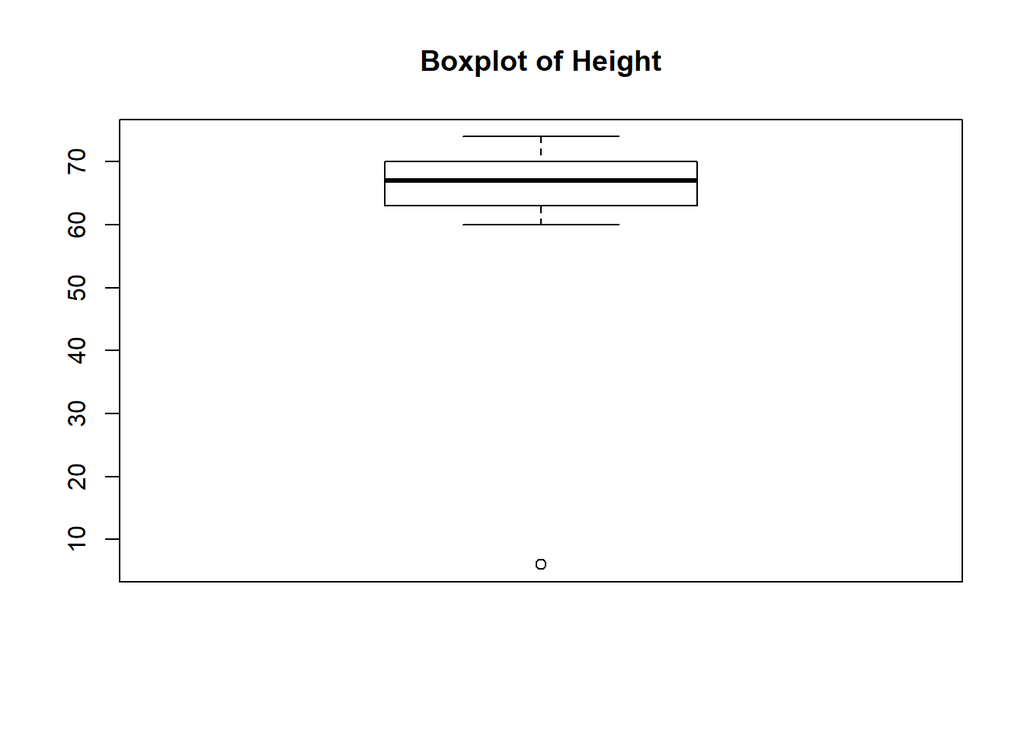

```r
a <- fivenum(Exercise$height)
#summary(Exercise$height) in summary mean is extra variable which is not needed

IQR <-a[4]-a[2]
boxplot(Exercise$height,main="Boxplot of Height")
```

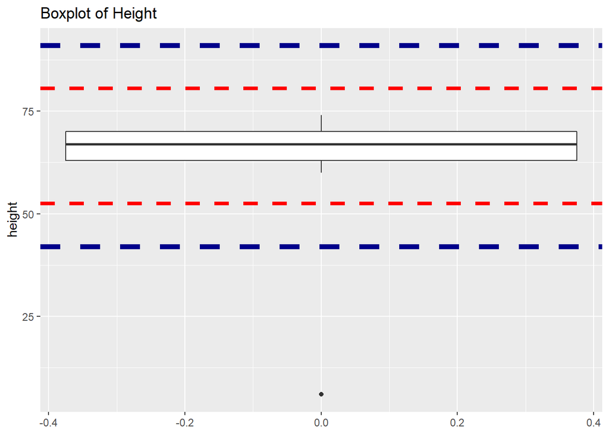

```r
IF1 <-a[2]-1.5*IQR
IF2 <- a[4]+1.5*IQR

OF1 <-a[2]-3*IQR
OF2 <-a[4]+3*IQR

f <- ggplot(Exercise,aes(y=height))
f+ geom_boxplot()+ggtitle("Boxplot of Height")+
   geom_hline(yintercept = c(IF1,IF2),linetype="dashed",color="red",size=1.5)+
   geom_hline(yintercept = c(OF1,OF2),linetype="dashed",color="darkblue",size=2)
```

### Q.3.a)All the variables are represented as integer. Write your own function that automatically converts all the integer variables to factors (categorical).

```r
library(MASS)
library(plyr)
library(dplyr)
library(tibble)


#?birthwt
#View(birthwt)
str(birthwt)
```

```
## 'data.frame':    189 obs. of  10 variables:
##  $ low  : int  0 0 0 0 0 0 0 0 0 0 ...
##  $ age  : int  19 33 20 21 18 21 22 17 29 26 ...
##  $ lwt  : int  182 155 105 108 107 124 118 103 123 113 ...
##  $ race : int  2 3 1 1 1 3 1 3 1 1 ...
##  $ smoke: int  0 0 1 1 1 0 0 0 1 1 ...
##  $ ptl  : int  0 0 0 0 0 0 0 0 0 0 ...
##  $ ht   : int  0 0 0 0 0 0 0 0 0 0 ...
##  $ ui   : int  1 0 0 1 1 0 0 0 0 0 ...
##  $ ftv  : int  0 3 1 2 0 0 1 1 1 0 ...
##  $ bwt  : int  2523 2551 2557 2594 2600 2622 2637 2637 2663 2665 ...
```

```r
converttofactor<-function(x){
  return(as.factor(x))

}


str(birthwt)
```

```
## 'data.frame':    189 obs. of  10 variables:
##  $ low  : int  0 0 0 0 0 0 0 0 0 0 ...
##  $ age  : int  19 33 20 21 18 21 22 17 29 26 ...
##  $ lwt  : int  182 155 105 108 107 124 118 103 123 113 ...
##  $ race : int  2 3 1 1 1 3 1 3 1 1 ...
##  $ smoke: int  0 0 1 1 1 0 0 0 1 1 ...
##  $ ptl  : int  0 0 0 0 0 0 0 0 0 0 ...
##  $ ht   : int  0 0 0 0 0 0 0 0 0 0 ...
##  $ ui   : int  1 0 0 1 1 0 0 0 0 0 ...
##  $ ftv  : int  0 3 1 2 0 0 1 1 1 0 ...
##  $ bwt  : int  2523 2551 2557 2594 2600 2622 2637 2637 2663 2665 ...
```

```r
 #c(1,4:9)
birthwt[,c(1,4,5,6,7,8,9)] <- lapply(birthwt[,c(1,4,5,6,7,8,9)],converttofactor)
str(birthwt)
```

```
## 'data.frame':    189 obs. of  10 variables:
##  $ low  : Factor w/ 2 levels "0","1": 1 1 1 1 1 1 1 1 1 1 ...
##  $ age  : int  19 33 20 21 18 21 22 17 29 26 ...
##  $ lwt  : int  182 155 105 108 107 124 118 103 123 113 ...
##  $ race : Factor w/ 3 levels "1","2","3": 2 3 1 1 1 3 1 3 1 1 ...
##  $ smoke: Factor w/ 2 levels "0","1": 1 1 2 2 2 1 1 1 2 2 ...
##  $ ptl  : Factor w/ 4 levels "0","1","2","3": 1 1 1 1 1 1 1 1 1 1 ...
##  $ ht   : Factor w/ 2 levels "0","1": 1 1 1 1 1 1 1 1 1 1 ...
##  $ ui   : Factor w/ 2 levels "0","1": 2 1 1 2 2 1 1 1 1 1 ...
##  $ ftv  : Factor w/ 6 levels "0","1","2","3",..: 1 4 2 3 1 1 2 2 2 1 ...
##  $ bwt  : int  2523 2551 2557 2594 2600 2622 2637 2637 2663 2665 ...
```

###Q.3.b) Repeat part (a) using mutate() and mapvalues() functions.

```r
library(plyr)
birthwt<-mutate(birthwt,
         race = as.factor(mapvalues(race , c("white", "black", "other"), c("1","2", "3"))),
         smoke =as.factor(mapvalues(smoke , c("no", "yes"), c("0","1"))),
         ptl = as.factor(mapvalues(ptl , c("no", "yes"), c("0","1"))),
         ht = as.factor(mapvalues(ht , c("no", "yes"), c("0","1"))),
         ui = as.factor(mapvalues(ui , c("no", "yes"), c("0","1"))),
         ftv = as.factor(mapvalues(ftv , c("no", "yes"), c("0","1"))),
         low = as.factor(mapvalues(low , c("no", "yes"), c("0","1"))))
```

### 3.c) Use the tapply() function to see what the average birthweight looks like when broken down by race and smoking status. Does smoking status appear to have an eï¬ect on birth weight? Does the eï¬ect of smoking status appear to be consistent across racial groups? What is the association between race and birth weight?

```r
tapply(birthwt$bwt, birthwt$race, mean)
```

```
##        1        2        3
## 3102.719 2719.692 2805.284
```

```r
tapply(birthwt$bwt, birthwt$smoke, mean)
```

```
##        0        1
## 3055.696 2771.919
```

```r
#Theory

#Yes, it looks like smoking status does have an effect on birth weight as average birth weight for non - smokers is 3055.6, however, for smokers it is 2771.92*

 # *Yes, the effect of smoking status appears to be consistent across racial groups as the average birth weight for smokers across all the races is comparatively lesser to non-smokers across the racial groups*

  #*We see that Race =1 (white) has the highest average birth weight (3102.72), Race =3 (Other) have a average birth weight of 2805.2 whereas for Race =2 (Black), the average birth weight is the lowest 2719.70*
```

[output not shown]

[output not shown]

### 3.d) Use kable() function from knitr to dispaly the table you get in part (c)

```r
library(knitr)
#install.packages("kableExtra")
library(kableExtra)
kable(birthwt) %>%
  kable_styling(bootstrap_options = c("striped", "hover"))
```

| low | age | lwt | race | smoke | ptl | ht | ui | ftv | bwt |
| --- | --- | --- | --- | --- | --- | --- | --- | --- | --- |
| 0 | 19 | 182 | 2 | 0 | 0 | 0 | 1 | 0 | 2523 |
| 0 | 33 | 155 | 3 | 0 | 0 | 0 | 0 | 3 | 2551 |
| 0 | 20 | 105 | 1 | 1 | 0 | 0 | 0 | 1 | 2557 |
| 0 | 21 | 108 | 1 | 1 | 0 | 0 | 1 | 2 | 2594 |
| 0 | 18 | 107 | 1 | 1 | 0 | 0 | 1 | 0 | 2600 |
| 0 | 21 | 124 | 3 | 0 | 0 | 0 | 0 | 0 | 2622 |
| 0 | 22 | 118 | 1 | 0 | 0 | 0 | 0 | 1 | 2637 |
| 0 | 17 | 103 | 3 | 0 | 0 | 0 | 0 | 1 | 2637 |
| 0 | 29 | 123 | 1 | 1 | 0 | 0 | 0 | 1 | 2663 |
| 0 | 26 | 113 | 1 | 1 | 0 | 0 | 0 | 0 | 2665 |
| 0 | 19 | 95 | 3 | 0 | 0 | 0 | 0 | 0 | 2722 |
| 0 | 19 | 150 | 3 | 0 | 0 | 0 | 0 | 1 | 2733 |
| 0 | 22 | 95 | 3 | 0 | 0 | 1 | 0 | 0 | 2751 |
| 0 | 30 | 107 | 3 | 0 | 1 | 0 | 1 | 2 | 2750 |
| 0 | 18 | 100 | 1 | 1 | 0 | 0 | 0 | 0 | 2769 |
| 0 | 18 | 100 | 1 | 1 | 0 | 0 | 0 | 0 | 2769 |
| 0 | 15 | 98 | 2 | 0 | 0 | 0 | 0 | 0 | 2778 |
| 0 | 25 | 118 | 1 | 1 | 0 | 0 | 0 | 3 | 2782 |
| 0 | 20 | 120 | 3 | 0 | 0 | 0 | 1 | 0 | 2807 |
| 0 | 28 | 120 | 1 | 1 | 0 | 0 | 0 | 1 | 2821 |
| 0 | 32 | 121 | 3 | 0 | 0 | 0 | 0 | 2 | 2835 |
| 0 | 31 | 100 | 1 | 0 | 0 | 0 | 1 | 3 | 2835 |
| 0 | 36 | 202 | 1 | 0 | 0 | 0 | 0 | 1 | 2836 |
| 0 | 28 | 120 | 3 | 0 | 0 | 0 | 0 | 0 | 2863 |
| 0 | 25 | 120 | 3 | 0 | 0 | 0 | 1 | 2 | 2877 |
| 0 | 28 | 167 | 1 | 0 | 0 | 0 | 0 | 0 | 2877 |
| 0 | 17 | 122 | 1 | 1 | 0 | 0 | 0 | 0 | 2906 |
| 0 | 29 | 150 | 1 | 0 | 0 | 0 | 0 | 2 | 2920 |
| 0 | 26 | 168 | 2 | 1 | 0 | 0 | 0 | 0 | 2920 |
| 0 | 17 | 113 | 2 | 0 | 0 | 0 | 0 | 1 | 2920 |

[output cut: 159 more lines]

### 3.e) Use ddply() function to get the average birthweight by motherâs race and compare it with tapply() function

```r
library(plyr)

table_d<-ddply(birthwt,.(race),summarize,mean_val=mean(bwt))
table_d
```

| race | mean_val |
| --- | --- |
| 1 | 3102.719 |
| 2 | 2719.692 |
| 3 | 2805.284 |

### 3.f) Use ggplot2() to plot the average birthweight (computed in part (e)) for each race group in a bar plot

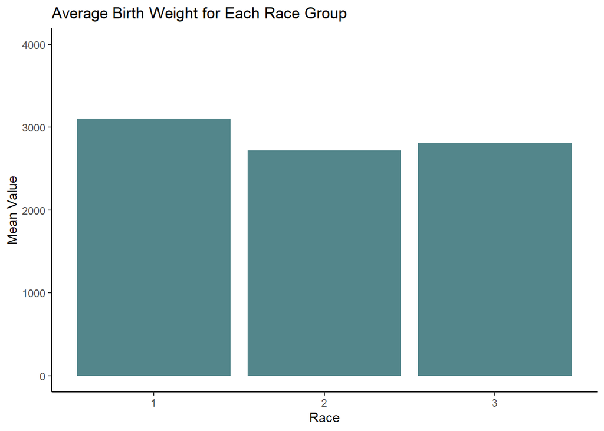

```r
library(ggplot2)

ggplot(data=table_d,aes(x=race,y=mean_val),) + geom_bar(stat = "identity",fill='cadetblue4') + xlab("Race") +
  ylab ("Mean Value") + ggtitle("Average Birth Weight for Each Race Group") + ylim(c(0,4000)) +
  theme(panel.grid=element_blank(),panel.background = element_blank(),
        axis.line = element_line(colour = "black"))
```

### 3.g) Use ddply() function to look at the average birthweight and proportion of babies with low birthweight broken down by smoking status

```r
str(birthwt)
```

```
## 'data.frame':    189 obs. of  10 variables:
##  $ low  : Factor w/ 2 levels "0","1": 1 1 1 1 1 1 1 1 1 1 ...
##  $ age  : int  19 33 20 21 18 21 22 17 29 26 ...
##  $ lwt  : int  182 155 105 108 107 124 118 103 123 113 ...
##  $ race : Factor w/ 3 levels "1","2","3": 2 3 1 1 1 3 1 3 1 1 ...
##  $ smoke: Factor w/ 2 levels "0","1": 1 1 2 2 2 1 1 1 2 2 ...
##  $ ptl  : Factor w/ 4 levels "0","1","2","3": 1 1 1 1 1 1 1 1 1 1 ...
##  $ ht   : Factor w/ 2 levels "0","1": 1 1 1 1 1 1 1 1 1 1 ...
##  $ ui   : Factor w/ 2 levels "0","1": 2 1 1 2 2 1 1 1 1 1 ...
##  $ ftv  : Factor w/ 6 levels "0","1","2","3",..: 1 4 2 3 1 1 2 2 2 1 ...
##  $ bwt  : int  2523 2551 2557 2594 2600 2622 2637 2637 2663 2665 ...
```

```r
table_g<-ddply(birthwt, ~ smoke, summarize,
      avg_wt = mean(bwt),
      low_birth_prop = mean(low == 1))

table_g
```

| smoke | avg_wt | low_birth_prop |
| --- | --- | --- |
| 0 | 3055.696 | 0.2521739 |
| 1 | 2771.919 | 0.4054054 |